# NBA Reproducible Data Analysis Project

Barsha Paudel (u3228464)

6/05/2022

## Introduction

National Basketball Association(NBA) is professional basketball league which is in North America. It is one of the major professional sports leagues in US and Canada which is composed of 30 teams out of which 29 is in United States and 1 in Canada.In 1949, August 3 the name of NBA was changed to National Basketball Association from the Basketball Association of America (BAA) after it got merged with the National Basketball League (NBL).The regular season of NBA runs from October to April with each teams playing 82 games. Now as of 2020, the player from NBA team has the world’s best paid athletes with average annual salary per player.

In this project I am working as a data analyst with the Chicago Bulls competing in National Basketball Association. This team’s budget for player contracts next season is $118 million. So the major purpose behind this data analysis is to find the best five starting players (one from each position) that the Chicago team can buy for the next season. We have to find the best five players making sure that the estimated budget is not just used for the 5 player because we still need to fill a full team roster, so have to just focus on finding five starting players here. I am allowed to choose the players that were already playing for Chicago Bulls in 2018-19, but just need to prove that they are worth it.

This reproducible data analysis on NBA will help the Chicago Bulls in finding good quality players with good points with deserving salary for the next season to help improve the team. The matrices I will use to evaluate the players by looking at the performances of the players from the available dataset. I will be evaluating the players on the basis of certain criteria mentioned below in the data modelling results and players recommendation part.The importance of this data analysis in finding the best five starting players is to make a good players team through which a team can focus on achieving a common goal. A good starting players can always focus on attracting defenders towards him and then they will always try to pass the ball to the open teammate.And the good players will always leads to the wins.Thus it is important to find the best starting players for NBA next season to better the performance of the whole team and to gain the success.

### Load required packages

```r
library(tidyverse)
library(readr)
library(ggplot2)
library(ggcorrplot)
library(reshape2)
library(broom)
```

### Data source

The data used in this document contains two datasets of National Basketball Association(NBA) and they are total statistics for individual NBA players during the 2018-19 season and the salary for individual players during the 2018-19 NBA season. We are using the data which has been sourced from: 2018-19_nba_player-statistics.csv : sourced from basketball-reference.com 2018-19_nba_player-salaries.csv : sourced from hoopshype.com/salaries

**Description of the datasets**

2018-19_nba_player-statistics.csv : The variables consists of: player_name : Player Name Pos : (PG = point guard, SG = shooting guard, SF = small forward, PF = power forward, C = center) Age : Age of Player at the start of February 1st of that season. Tm : Team G : Games GS : Games Started MP : Minutes Played FG : Field Goals FGA : Field Goal Attempts FG% : Field Goal Percentage 3P : 3-Point Field Goals 3PA : 3-Point Field Goal Attempts 3P% : FG% on 3-Pt FGAs 2P : 2-Point Field Goals 2PA : 2-point Field Goal Attempts 2P% : FG% on 2-Pt FGAs eFG% : Effective Field Goal Percentage FT : Free Throws FTA : Free Throw Attempts FT% : Free Throw Percentage ORB : Offensive Rebounds DRB : Defensive Rebounds TRB : Total Rebounds AST : Assists STL : Steals BLK : Blocks TOV : Turnovers PF : Personal Fouls PTS : Points

2018-19_nba_player-salaries.csv: The variables consists of: player_id : unique player identification number player_name : player name salary : year salary in $USD

## Read data

Reading the data file using the `read_csv()` function from the `readr` package.

```r
salaries <- read_csv("2018-19_nba_player-salaries.csv")
statistics <- read_csv("2018-19_nba_player-statistics.csv")
```

### Checking the data

Checking the structure of the data file using `str()`:

```r
str(salaries)
```

```
## spec_tbl_df [576 x 3] (S3: spec_tbl_df/tbl_df/tbl/data.frame)
##  $ player_id  : num [1:576] 1 2 3 4 5 6 7 8 9 10 ...
##  $ player_name: chr [1:576] "Alex Abrines" "Quincy Acy" "Steven Adams" "Jaylen Adams" ...
##  $ salary     : num [1:576] 3667645 213948 24157304 236854 2955840 ...
##  - attr(*, "spec")=
##   .. cols(
##   ..   player_id = col_double(),
##   ..   player_name = col_character(),
##   ..   salary = col_double()
##   .. )
##  - attr(*, "problems")=<externalptr>
```

```r
str(statistics)
```

```
## spec_tbl_df [708 x 29] (S3: spec_tbl_df/tbl_df/tbl/data.frame)
##  $ player_name: chr [1:708] "Alex Abrines" "Quincy Acy" "Jaylen Adams" "Steven Adams" ...
##  $ Pos        : chr [1:708] "SG" "PF" "PG" "C" ...
##  $ Age        : num [1:708] 25 28 22 25 21 21 25 33 21 23 ...
##  $ Tm         : chr [1:708] "OKC" "PHO" "ATL" "OKC" ...
##  $ G          : num [1:708] 31 10 34 80 82 19 7 81 10 38 ...
##  $ GS         : num [1:708] 2 0 1 80 28 3 0 81 1 2 ...
##  $ MP         : num [1:708] 588 123 428 2669 1913 ...
##  $ FG         : num [1:708] 56 4 38 481 280 11 3 684 13 67 ...
##  $ FGA        : num [1:708] 157 18 110 809 486 ...
##  $ FG%        : num [1:708] 0.357 0.222 0.345 0.595 0.576 0.306 0.3 0.519 0.333 0.376 ...
##  $ 3P         : num [1:708] 41 2 25 0 3 6 0 10 3 32 ...
##  $ 3PA        : num [1:708] 127 15 74 2 15 23 4 42 12 99 ...
##  $ 3P%        : num [1:708] 0.323 0.133 0.338 0 0.2 0.261 0 0.238 0.25 0.323 ...
##  $ 2P         : num [1:708] 15 2 13 481 277 5 3 674 10 35 ...
##  $ 2PA        : num [1:708] 30 3 36 807 471 ...
##  $ 2P%        : num [1:708] 0.5 0.667 0.361 0.596 0.588 0.385 0.5 0.528 0.37 0.443 ...
##  $ eFG%       : num [1:708] 0.487 0.278 0.459 0.595 0.579 0.389 0.3 0.522 0.372 0.466 ...
##  $ FT         : num [1:708] 12 7 7 146 166 4 1 349 8 45 ...
##  $ FTA        : num [1:708] 13 10 9 292 226 4 2 412 12 60 ...
##  $ FT%        : num [1:708] 0.923 0.7 0.778 0.5 0.735 1 0.5 0.847 0.667 0.75 ...
##  $ ORB        : num [1:708] 5 3 11 391 165 3 1 251 11 3 ...
##  $ DRB        : num [1:708] 43 22 49 369 432 16 3 493 15 20 ...
##  $ TRB        : num [1:708] 48 25 60 760 597 19 4 744 26 23 ...
##  $ AST        : num [1:708] 20 8 65 124 184 5 6 194 13 25 ...
##  $ STL        : num [1:708] 17 1 14 117 71 1 2 43 1 6 ...
##  $ BLK        : num [1:708] 6 4 5 76 65 4 0 107 0 6 ...
##  $ TOV        : num [1:708] 14 4 28 135 121 6 2 144 8 33 ...
##  $ PF         : num [1:708] 53 24 45 204 203 13 4 179 7 47 ...
##  $ PTS        : num [1:708] 165 17 108 1108 729 ...
##  - attr(*, "spec")=
##   .. cols(
##   ..   player_name = col_character(),
##   ..   Pos = col_character(),
##   ..   Age = col_double(),
##   ..   Tm = col_character(),
##   ..   G = col_double(),
##   ..   GS = col_double(),
##   ..   MP = col_double(),
##   ..   FG = col_double(),
```

[output cut: 8 more lines]

```
##   ..   `eFG%` = col_double(),
##   ..   FT = col_double(),
##   ..   FTA = col_double(),
##   ..   `FT%` = col_double(),
##   ..   ORB = col_double(),
##   ..   DRB = col_double(),
##   ..   TRB = col_double(),
##   ..   AST = col_double(),
##   ..   STL = col_double(),
##   ..   BLK = col_double(),
##   ..   TOV = col_double(),
##   ..   PF = col_double(),
##   ..   PTS = col_double()
##   .. )
##  - attr(*, "problems")=<externalptr>
```

Checking the first 6 rows of the data file using `head()`

```r
head(salaries)
```

```
## # A tibble: 6 x 3
##   player_id player_name    salary
##       <dbl> <chr>           <dbl>
## 1         1 Alex Abrines  3667645
## 2         2 Quincy Acy     213948
## 3         3 Steven Adams 24157304
## 4         4 Jaylen Adams   236854
## 5         5 Bam Adebayo   2955840
## 6         6 Deng Adel       77250
```

```r
head(statistics)
```

```
## # A tibble: 6 x 29
##   player_name  Pos     Age Tm        G    GS    MP    FG   FGA `FG%`  `3P` `3PA`
##   <chr>        <chr> <dbl> <chr> <dbl> <dbl> <dbl> <dbl> <dbl> <dbl> <dbl> <dbl>
## 1 Alex Abrines SG       25 OKC      31     2   588    56   157 0.357    41   127
## 2 Quincy Acy   PF       28 PHO      10     0   123     4    18 0.222     2    15
## 3 Jaylen Adams PG       22 ATL      34     1   428    38   110 0.345    25    74
## 4 Steven Adams C        25 OKC      80    80  2669   481   809 0.595     0     2
## 5 Bam Adebayo  C        21 MIA      82    28  1913   280   486 0.576     3    15
## 6 Deng Adel    SF       21 CLE      19     3   194    11    36 0.306     6    23
## # ... with 17 more variables: 3P% <dbl>, 2P <dbl>, 2PA <dbl>, 2P% <dbl>,
## #   eFG% <dbl>, FT <dbl>, FTA <dbl>, FT% <dbl>, ORB <dbl>, DRB <dbl>,
## #   TRB <dbl>, AST <dbl>, STL <dbl>, BLK <dbl>, TOV <dbl>, PF <dbl>, PTS <dbl>
```

Checking the last 6 rows of the data file using `tail()`

```r
tail(salaries)
```

```
## # A tibble: 6 x 3
##   player_id player_name    salary
##       <dbl> <chr>           <dbl>
## 1       571 Rade Zagorac  1378242
## 2       572 Cody Zeller  13528090
## 3       573 Tyler Zeller   213948
## 4       574 Ante Zizic    1952760
## 5       575 Ivica Zubac   1544951
## 6       576 Nene          3651480
```

```r
tail(statistics)
```

```
## # A tibble: 6 x 29
##   player_name Pos     Age Tm        G    GS    MP    FG   FGA `FG%`  `3P` `3PA`
##   <chr>       <chr> <dbl> <chr> <dbl> <dbl> <dbl> <dbl> <dbl> <dbl> <dbl> <dbl>
## 1 Ivica Zubac C        21 LAL      33    12   516   112   193 0.58      0     0
## 2 Ivica Zubac C        21 TOT      59    37  1040   212   379 0.559     0     0
## 3 Dario Saric PF       24 PHI      13    13   396    48   132 0.364    21    70
## 4 Dario Saric PF       24 MIN      68    28  1627   256   564 0.454    97   253
## 5 Dario Saric PF       24 TOT      81    41  2023   304   696 0.437   118   323
## 6 Ante Zizic  C        22 CLE      59    25  1082   183   331 0.553     0     0
## # ... with 17 more variables: 3P% <dbl>, 2P <dbl>, 2PA <dbl>, 2P% <dbl>,
## #   eFG% <dbl>, FT <dbl>, FTA <dbl>, FT% <dbl>, ORB <dbl>, DRB <dbl>,
## #   TRB <dbl>, AST <dbl>, STL <dbl>, BLK <dbl>, TOV <dbl>, PF <dbl>, PTS <dbl>
```

Checking for missing values using:

```r
sum(is.na(salaries))
```

```
## [1] 0
```

```r
sum(is.na(statistics))
```

```
## [1] 117
```

Comments: There is no missing values on salaries datasets but there is 117 missing values in statistics datasets

### Visualizing missing values

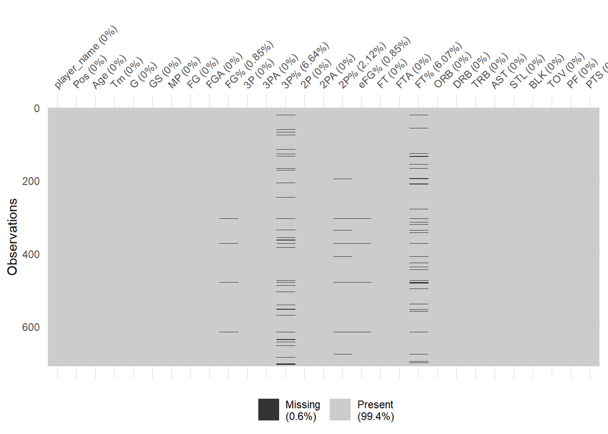

```r
naniar::vis_miss(statistics)
```

Dropping mising values:

```r
player_statistics <- drop_na(statistics) #storing cleaned datasets in player_statistics
```

**Merging Datasets:**

Merging salaries dataset and player statistics dataset by player name using merge() function

```r
merged_data <- merge(salaries, player_statistics, by = "player_name", all = TRUE)
```

Checking the missing values of merged dataset

```r
sum(is.na(merged_data))
```

```
## [1] 3314
```

Dropping the missing values

```r
merged_data <- drop_na(merged_data)
```

Removing duplicates of merged data:

We can see many duplicates in the merged datasets so removing all those duplicates using duplicated function

```r
players_cleaned_data <- merged_data[!duplicated(merged_data$player_name, merged_data$player_id), ]
```

## Exploratory data analysis

**What is the salary distribution of the players?**

Salary distribution using histogram

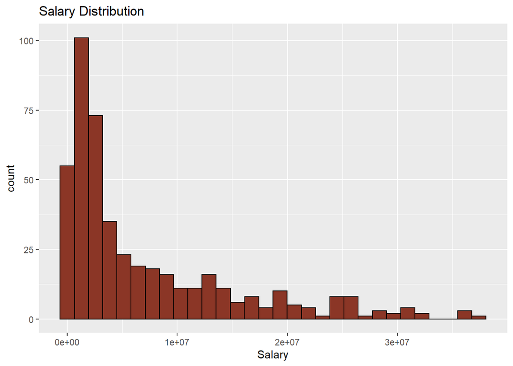

```r
ggplot(players_cleaned_data, aes(x = salary)) +
  geom_histogram(col = "black", fill = "tomato4")+
  xlab("Salary")+
  ggtitle("Salary Distribution")
```

**What is the age distribution of the players?**

Age distribution using histogram

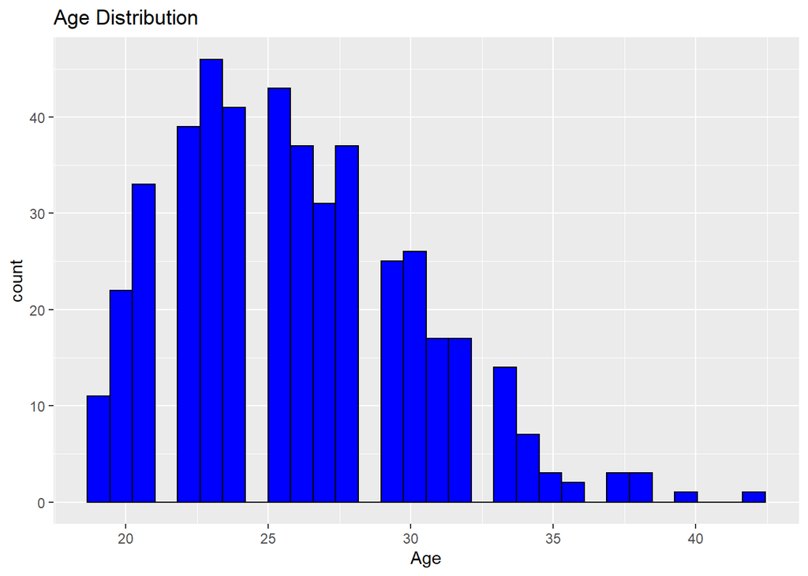

```r
ggplot(players_cleaned_data, aes(Age)) +
  geom_histogram(col = "black", fill = "blue")+
  xlab("Age")+
  ggtitle("Age Distribution")
```

Comments: From the plot we can interpret that the age distribution of the payers is between 20-40 years, most of the players age group is 20-30,and very less players are above 35+ age.

**How is age and salary of players related to each other?**

Displaying the relationship between Age and Salary

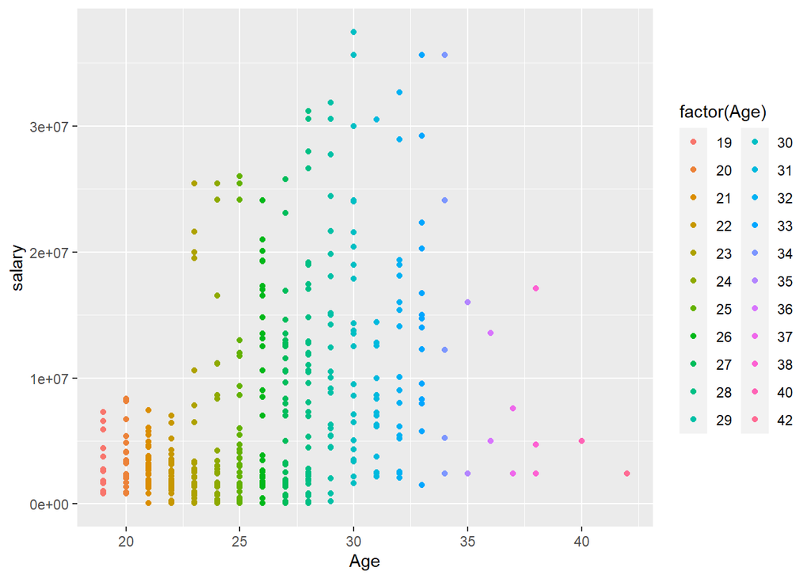

```r
ggplot(players_cleaned_data, aes(Age, salary)) +
    geom_point(aes(colour = factor(Age)))
```

Comments: From the plot we can interpret that the players who are at their early 20s earns less salary comparing to the earnings of the players who are at the age of 25-35.There are very less players at the age of 40 and earns less as well.

**How does players positions and points affects the players earning?**

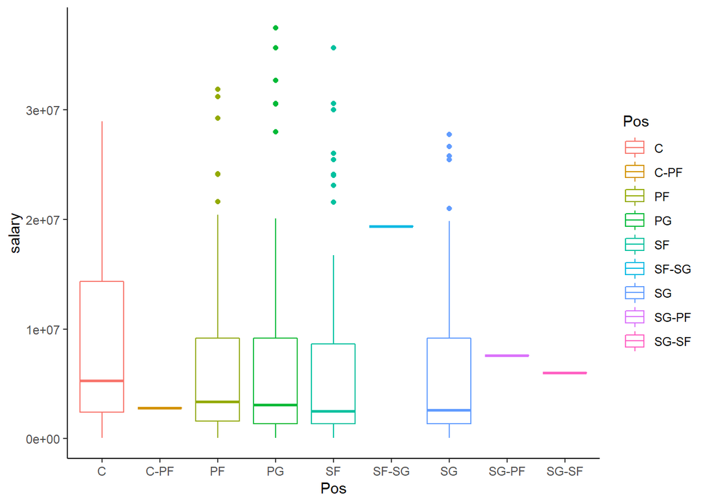

```r
ggplot(data = players_cleaned_data, aes(x= Pos, y = salary, color= Pos))+
  geom_boxplot()+
  theme_classic()
```

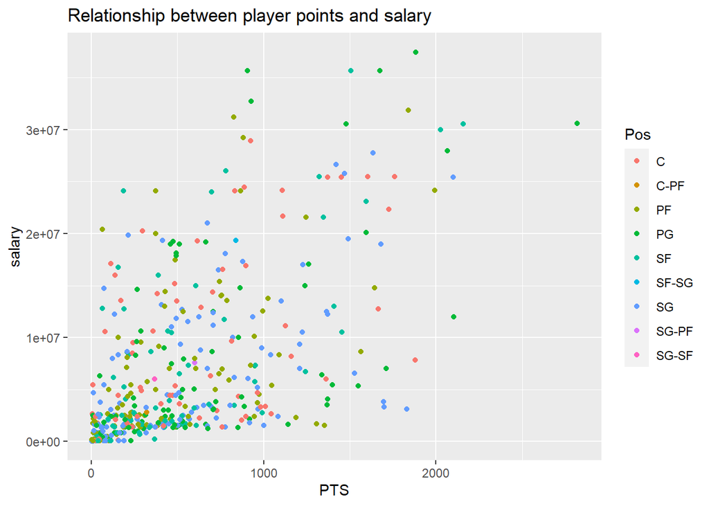

```r
ggplot(data = players_cleaned_data, aes(x = PTS, y = salary, color = Pos)) +
  geom_point()+
  ggtitle("Relationship between player points and salary")
```

Comments: From the plot we can interpret that the player points and salary has a positive relationship with each other. The increase in players points will increase the players salary and vice-versa.

**Does the minutes played by a players influence players points?**

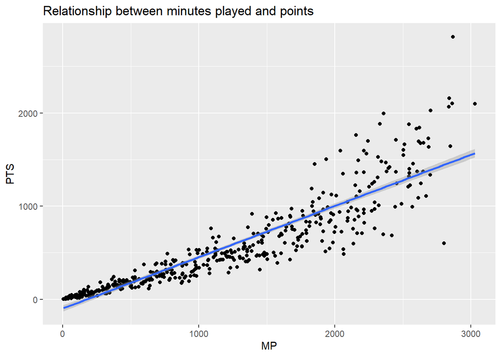

```r
ggplot(data = players_cleaned_data, aes(x = MP, y = PTS)) +
  geom_point() +
  ggtitle("Relationship between minutes played and points") +geom_smooth(method = lm)
```

Comments: Looking at the plot we can interpret that the more minutes given to the players to play will help increasing in players points. Therefore there is a positive relationship between minutes played and players points.

## Correlation Heatmap

Now checking the relationship between all numeric variables, therefore removing non-numeric variables from the players_cleaned dataset

```r
numeric_variables <- select(players_cleaned_data,-c(player_name, Pos, Tm))


round(x = cor(numeric_variables), digits = 2)
```

```
##           player_id salary   Age     G    GS    MP    FG   FGA   FG%    3P
## player_id      1.00  -0.04 -0.03 -0.06 -0.03 -0.05 -0.02 -0.01  0.04 -0.02
## salary        -0.04   1.00  0.39  0.34  0.52  0.52  0.58  0.58  0.16  0.44
## Age           -0.03   0.39  1.00  0.09  0.04  0.09  0.05  0.06  0.02  0.15
## G             -0.06   0.34  0.09  1.00  0.63  0.89  0.74  0.75  0.30  0.61
## GS            -0.03   0.52  0.04  0.63  1.00  0.86  0.82  0.82  0.23  0.63
## MP            -0.05   0.52  0.09  0.89  0.86  1.00  0.92  0.92  0.27  0.75
## FG            -0.02   0.58  0.05  0.74  0.82  0.92  1.00  0.99  0.32  0.72
## FGA           -0.01   0.58  0.06  0.75  0.82  0.92  0.99  1.00  0.23  0.79
## FG%            0.04   0.16  0.02  0.30  0.23  0.27  0.32  0.23  1.00 -0.03
## 3P            -0.02   0.44  0.15  0.61  0.63  0.75  0.72  0.79 -0.03  1.00
## 3PA           -0.02   0.45  0.14  0.63  0.64  0.77  0.74  0.81 -0.04  0.99
## 3P%            0.02   0.07  0.07  0.16  0.16  0.20  0.16  0.19  0.07  0.37
## 2P            -0.02   0.55  0.00  0.68  0.77  0.84  0.96  0.91  0.42  0.49
## 2PA            0.00   0.56  0.00  0.69  0.78  0.86  0.96  0.94  0.35  0.53
## 2P%           -0.03   0.06  0.01  0.19  0.12  0.16  0.18  0.11  0.76 -0.01
## eFG%           0.03   0.15  0.11  0.35  0.24  0.31  0.30  0.25  0.87  0.21
## FT            -0.04   0.59  0.05  0.59  0.71  0.77  0.89  0.88  0.26  0.61
## FTA           -0.04   0.59  0.04  0.60  0.71  0.78  0.90  0.88  0.30  0.56
## FT%           -0.10   0.16  0.20  0.24  0.20  0.26  0.24  0.26 -0.06  0.34
## ORB           -0.06   0.35 -0.01  0.56  0.54  0.58  0.60  0.51  0.51  0.10
## DRB           -0.04   0.53  0.07  0.72  0.75  0.82  0.83  0.79  0.40  0.46
## TRB           -0.05   0.50  0.05  0.70  0.72  0.79  0.80  0.74  0.45  0.38
## AST            0.03   0.54  0.11  0.60  0.70  0.77  0.77  0.79  0.15  0.60
## STL           -0.01   0.53  0.08  0.73  0.77  0.86  0.79  0.80  0.20  0.63
## BLK           -0.04   0.35  0.02  0.54  0.56  0.58  0.58  0.51  0.41  0.20
## TOV            0.02   0.57  0.04  0.68  0.77  0.85  0.91  0.91  0.24  0.64
## PF            -0.05   0.42  0.05  0.86  0.76  0.90  0.80  0.78  0.36  0.56
## PTS           -0.03   0.60  0.07  0.73  0.82  0.91  0.99  0.99  0.28  0.77
##             3PA   3P%    2P  2PA   2P% eFG%    FT   FTA   FT%   ORB   DRB   TRB
## player_id -0.02  0.02 -0.02 0.00 -0.03 0.03 -0.04 -0.04 -0.10 -0.06 -0.04 -0.05
## salary     0.45  0.07  0.55 0.56  0.06 0.15  0.59  0.59  0.16  0.35  0.53  0.50
## Age        0.14  0.07  0.00 0.00  0.01 0.11  0.05  0.04  0.20 -0.01  0.07  0.05
## G          0.63  0.16  0.68 0.69  0.19 0.35  0.59  0.60  0.24  0.56  0.72  0.70
## GS         0.64  0.16  0.77 0.78  0.12 0.24  0.71  0.71  0.20  0.54  0.75  0.72
## MP         0.77  0.20  0.84 0.86  0.16 0.31  0.77  0.78  0.26  0.58  0.82  0.79
## FG         0.74  0.16  0.96 0.96  0.18 0.30  0.89  0.90  0.24  0.60  0.83  0.80
## FGA        0.81  0.19  0.91 0.94  0.11 0.25  0.88  0.88  0.26  0.51  0.79  0.74
## FG%       -0.04  0.07  0.42 0.35  0.76 0.87  0.26  0.30 -0.06  0.51  0.40  0.45
## 3P         0.99  0.37  0.49 0.53 -0.01 0.21  0.61  0.56  0.34  0.10  0.46  0.38
```

[output cut: 32 more lines]

```
## 2PA       0.75  0.75  0.60 0.89  0.76  0.94
## 2P%       0.06  0.11  0.30 0.12  0.23  0.16
## eFG%      0.14  0.22  0.31 0.21  0.35  0.29
## FT        0.73  0.68  0.51 0.88  0.68  0.92
## FTA       0.73  0.70  0.55 0.89  0.71  0.92
## FT%       0.20  0.18  0.04 0.19  0.17  0.26
## ORB       0.31  0.51  0.75 0.52  0.71  0.55
## DRB       0.61  0.72  0.75 0.78  0.83  0.81
## TRB       0.55  0.69  0.78 0.74  0.83  0.77
## AST       1.00  0.79  0.30 0.90  0.62  0.78
## STL       0.79  1.00  0.49 0.80  0.78  0.79
## BLK       0.30  0.49  1.00 0.49  0.67  0.55
## TOV       0.90  0.80  0.49 1.00  0.77  0.91
## PF        0.62  0.78  0.67 0.77  1.00  0.78
## PTS       0.78  0.79  0.55 0.91  0.78  1.00
```

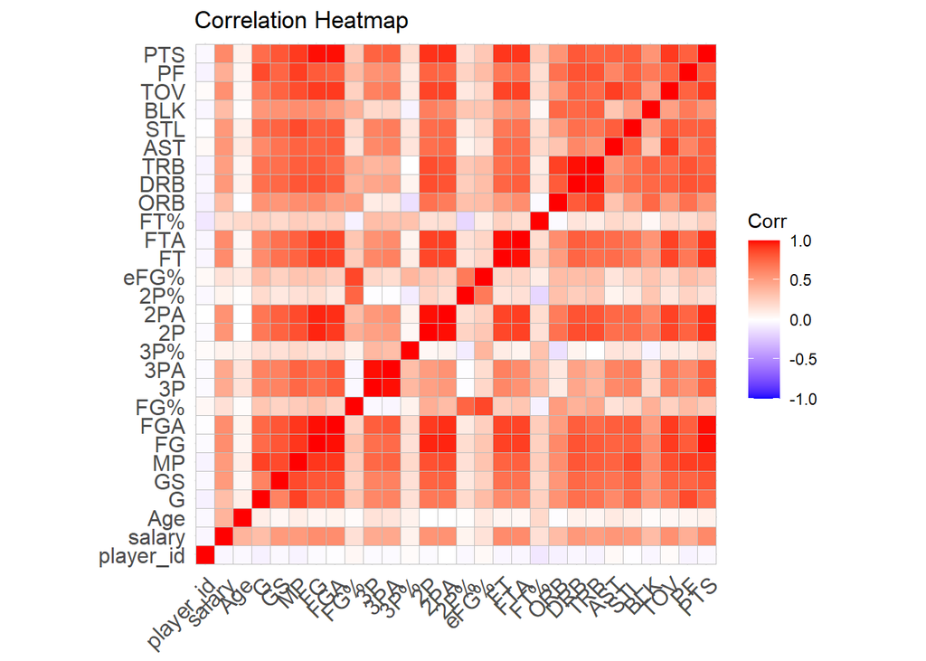

```r
ggcorrplot(cor(numeric_variables)) +
  ggtitle("Correlation Heatmap")
```

Comments:From the correlation heat map we can clearly identify the relationship between the variables. Lighter color in the heat map represents weak relationship among the variables and darker color in the heat map represents strong relationship among the variables.

## Data modelling and Results

In this part we have to select the variables to be used for the modelling the data. We are conducting the linear regression model players Points (PTS) based on Position,AGE, games, games started, minutes played, field goals, field goals attempts, free throws, free throws attempts, defensive rebounds, total rebounds, turnovers

```r
fit <- lm(PTS~ Pos+ Age+ G+ GS+ MP+ FG+ FGA+ FT+ FTA+ DRB+ TRB+ TOV, data = players_cleaned_data)
tidy(fit, conf.int = TRUE)
```

```
## # A tibble: 20 x 7
##    term        estimate std.error statistic  p.value conf.low conf.high
##    <chr>          <dbl>     <dbl>     <dbl>    <dbl>    <dbl>     <dbl>
##  1 (Intercept) -25.4      9.18       -2.77  5.82e- 3 -43.5    -7.40
##  2 PosC-PF      16.8     24.4         0.687 4.92e- 1 -31.2    64.8
##  3 PosPF         6.29     4.36        1.44  1.50e- 1  -2.28   14.9
##  4 PosPG        -7.02     5.19       -1.35  1.77e- 1 -17.2     3.18
##  5 PosSF         2.23     4.91        0.455 6.49e- 1  -7.41   11.9
##  6 PosSF-SG     15.9     24.8         0.639 5.23e- 1 -32.9    64.6
##  7 PosSG         3.15     4.97        0.633 5.27e- 1  -6.62   12.9
##  8 PosSG-PF     39.6     24.6         1.61  1.09e- 1  -8.80   88.0
##  9 PosSG-SF    -31.4     24.4        -1.29  1.99e- 1 -79.4    16.6
## 10 Age           0.834    0.281       2.97  3.13e- 3   0.282   1.39
## 11 G            -0.0405   0.129      -0.315 7.53e- 1  -0.293   0.212
## 12 GS           -0.0497   0.0951     -0.522 6.02e- 1  -0.237   0.137
## 13 MP            0.0275   0.00780     3.53  4.60e- 4   0.0122  0.0429
## 14 FG            1.59     0.0574     27.7   3.03e-98   1.48    1.70
## 15 FGA           0.320    0.0285     11.2   6.83e-26   0.264   0.376
## 16 FT            1.60     0.0975     16.4   1.06e-47   1.41    1.79
## 17 FTA          -0.554    0.0834     -6.64  9.35e-11  -0.718  -0.390
## 18 DRB           0.193    0.0600      3.21  1.42e- 3   0.0747  0.310
## 19 TRB          -0.195    0.0482     -4.04  6.28e- 5  -0.290  -0.100
## 20 TOV          -0.110    0.0557     -1.98  4.88e- 2  -0.220  -0.000594
```

```r
summary(fit)
```

```
##
## Call:
## lm(formula = PTS ~ Pos + Age + G + GS + MP + FG + FGA + FT +
##     FTA + DRB + TRB + TOV, data = players_cleaned_data)
##
## Residuals:
##      Min       1Q   Median       3Q      Max
## -165.986  -10.024    0.089    9.047  165.347
##
## Coefficients:
##              Estimate Std. Error t value Pr(>|t|)
## (Intercept) -25.44102    9.17913  -2.772  0.00582 **
## PosC-PF      16.78392   24.42682   0.687  0.49238
## PosPF         6.28820    4.36202   1.442  0.15013
## PosPG        -7.01990    5.18835  -1.353  0.17675
## PosSF         2.23188    4.90651   0.455  0.64942
## PosSF-SG     15.86766   24.81938   0.639  0.52294
## PosSG         3.14577    4.96910   0.633  0.52702
## PosSG-PF     39.57508   24.61532   1.608  0.10861
## PosSG-SF    -31.39806   24.41666  -1.286  0.19915
## Age           0.83373    0.28062   2.971  0.00313 **
## G            -0.04051    0.12865  -0.315  0.75297
## GS           -0.04966    0.09510  -0.522  0.60184
## MP            0.02753    0.00780   3.530  0.00046 ***
## FG            1.58900    0.05744  27.663  < 2e-16 ***
## FGA           0.32004    0.02850  11.229  < 2e-16 ***
## FT            1.60336    0.09749  16.447  < 2e-16 ***
## FTA          -0.55390    0.08343  -6.639 9.35e-11 ***
## DRB           0.19258    0.05996   3.212  0.00142 **
## TRB          -0.19493    0.04824  -4.041 6.28e-05 ***
## TOV          -0.11010    0.05572  -1.976  0.04877 *
## ---
## Signif. codes:  0 '***' 0.001 '**' 0.01 '*' 0.05 '.' 0.1 ' ' 1
##
## Residual standard error: 23.94 on 439 degrees of freedom
## Multiple R-squared:  0.9978, Adjusted R-squared:  0.9977
## F-statistic: 1.03e+04 on 19 and 439 DF,  p-value: < 2.2e-16
```

Comments: Looking at the summary of this model we can interpret that AGE, minutes played, field goals, field goals attempts, free throws,and defensive rebounds will contribute to a player having a higher points. The r-squared values is 0.9977 thus we can say that the players can have high points if the player has a better statistics.

## Features Selection

```r
new_data <- select(players_cleaned_data, c(salary, player_name, PTS,Pos, MP, G))
```

arranging the players point from highest to lowest

```r
high_low_data <- new_data%>%
  arrange(desc(PTS))
```

checking the summary of PTS, salary, MP and G

```r
summary(high_low_data$PTS)
```

```
##    Min. 1st Qu.  Median    Mean 3rd Qu.    Max.
##     2.0   146.0   421.0   537.3   783.5  2818.0
```

```r
summary(high_low_data$salary)
```

```
##     Min.  1st Qu.   Median     Mean  3rd Qu.     Max.
##    47370  1528776  3258539  6967454 10275646 37457154
```

```r
summary(high_low_data$MP)
```

```
##    Min. 1st Qu.  Median    Mean 3rd Qu.    Max.
##     5.0   400.5  1071.0  1153.4  1835.0  3028.0
```

```r
summary(high_low_data$G)
```

```
##    Min. 1st Qu.  Median    Mean 3rd Qu.    Max.
##    1.00   29.00   54.00   49.91   73.00   82.00
```

## Player Recommendation

Here we are finding the top five players by positions using filter function. We will set the criteria being based on the summary of the chosen variables printed above. In most of the criteria we will take median and maximum values from the summary of the chosen variables and will filter the data accordingly which will help us finding the top five players by positions.It is important to set the criteria because through that we will be able to find out the best players with more points achieved with more games and minutes played. Depending on the criteria we will be able to select the five best starting players who can actually improve in shooting percentages that can help make his/her team win more games.

Criteria are as follows: minimum of 421 points achieved salary should be between 3 million to 20 million minimum of 1071 minutes should be played minumum of 54 games played

**Finding the players based on the conditions from five different positions**

**Point_Guard**

```r
position_PG <- high_low_data %>%
  filter(Pos == "PG") %>%
  filter(G >=54,
         MP>=1071,
         salary>=3258539,
         salary<= 20000000,
         PTS>=421)

position_PG
```

```
##      salary             player_name  PTS Pos   MP  G
## 1  12000000            Kemba Walker 2102  PG 2863 82
## 2   7019698        D'Angelo Russell 1712  PG 2448 81
## 3   5363280              Trae Young 1549  PG 2503 81
## 4   5470920            De'Aaron Fox 1399  PG 2546 81
## 5   4073760           Collin Sexton 1371  PG 2605 82
## 6   3499800            Jamal Murray 1367  PG 2447 75
## 7   6434520             Ben Simmons 1337  PG 2700 79
## 8  17043478          Reggie Jackson 1260  PG 2289 82
## 9  15000000            Eric Bledsoe 1241  PG 2272 78
## 10  7250000             DJ Augustin  948  PG 2269 81
## 11  3375360 Shai Gilgeous-Alexander  889  PG 2174 82
## 12  4294479         Emmanuel Mudiay  873  PG 1607 59
## 13 14800000             Ricky Rubio  864  PG 1899 68
## 14 10000000         Darren Collison  853  PG 2143 76
## 15 12516746              Jeremy Lin  707  PG 1436 74
## 16  8653847           Fred VanVleet  701  PG 1760 64
## 17  5027028        Patrick Beverley  596  PG 2137 78
## 18  7945000             Cory Joseph  537  PG 2063 82
## 19 17868853             Evan Turner  494  PG 1605 73
## 20 19000000             George Hill  458  PG 1302 60
```

Comments:The first player to recommend to Chicago Bulls competing to NBA having the position of Point Guard(PG) is Kemba Walker with the 12 million salary, 2102 Points(PTS), 2863 Minutes Played(MP) and 82 Games.

**Shooting_Guard**

```r
position_SG <- high_low_data %>%
  filter(Pos == "SG") %>%
  filter(G >=54,
         MP>=1071,
         salary>=3258539,
         salary<= 20000000,
         PTS>=421)

position_SG
```

```
##      salary              player_name  PTS Pos   MP  G
## 1   3314365             Devin Booker 1700  SG 2242 64
## 2   3833760              Buddy Hield 1695  SG 2615 82
## 3  18988725            Klay Thompson 1680  SG 2652 78
## 4   6569040              Luka Doncic 1526  SG 2318 72
## 5  19500000              Zach LaVine 1492  SG 2171 63
## 6  12250000                JJ Redick 1372  SG 2379 76
## 7  12500000          Jordan Clarkson 1364  SG 2214 81
## 8  17000000            Evan Fournier 1226  SG 2553 81
## 9  10500000            Terrence Ross 1223  SG 2150 81
## 10  9367200          Josh Richardson 1209  SG 2539 73
## 11  7000000              Jeremy Lamb 1208  SG 2250 79
## 12 13500375              Eric Gordon 1103  SG 2158 68
## 13  8333333               Joe Harris 1041  SG 2293 76
## 14  9000000        Bogdan Bogdanovic  990  SG 1947 70
```

[output cut: 20 more lines]

Comments:The second player to recommend to Chicago Bulls competing to NBA having the position of Shooting Guard(SG) is Devin Booker with the 3.3 million salary, 1700 Points(PTS), 2242 Minutes Played(MP) and 64 Games.

**Small Forward**

```r
position_SF <- high_low_data %>%
  filter(Pos == "SF") %>%
  filter(G >=54,
         MP>=1071,
         salary>=3258539,
         salary<= 20000000,
         PTS>=421)

position_SF
```

```
##      salary      player_name  PTS Pos   MP  G
## 1  10500000 Bojan Bogdanovic 1454  SF 2573 81
## 2  13000000  Khris Middleton 1407  SF 2393 77
## 3   6700800     Jayson Tatum 1243  SF 2455 79
## 4   7305825      Jae Crowder  951  SF 2166 80
## 5   3448926  Justise Winslow  830  SF 1959 66
## 6   3557400    Mikal Bridges  684  SF 2417 82
## 7   7333334   Doug McDermott  564  SF 1340 77
## 8   6500000    Mario Hezonja  511  SF 1206 58
## 9   3940401  Stanley Johnson  454  SF 1208 66
## 10 10607143       Tony Snell  444  SF 1304 74
```

Comments:The third player to recommend to Chicago Bulls competing to NBA having the position of Small Forward(SF) is Bojan Bogdanovic with the 10.5 million salary, 1454 Points(PTS), 2573 Minutes Played(MP) and 81 Games.

**Power Forward**

```r
position_PF <- high_low_data %>%
  filter(Pos == "PF") %>%
  filter(G >=54,
         MP>=1071,
         salary>=3258539,
         salary<= 20000000,
         PTS>=421)

position_PF
```

```
##      salary            player_name  PTS Pos   MP  G
## 1  14800000          Tobias Harris 1644  PF 2847 82
## 2   8641000          Julius Randle 1565  PF 2232 73
## 3   8333333           Jerami Grant 1090  PF 2612 80
## 4   5375000          Marcus Morris 1046  PF 2091 75
## 5  13764045         Thaddeus Young 1024  PF 2489 81
## 6  12545455             Joe Ingles  994  PF 2568 82
## 7   3744840             Kevin Knox  963  PF 2158 75
## 8  10087200               Rudy Gay  946  PF 1842 69
## 9   7314960          Marvin Bagley  923  PF 1567 62
## 10  5922720          Jaren Jackson  798  PF 1515 58
## 11 13537527           Kelly Olynyk  787  PF 1812 79
## 12  6957105        Al-Farouq Aminu  760  PF 2292 81
## 13 14087500        Marvin Williams  756  PF 2133 75
## 14 14000000             Taj Gibson  753  PF 1686 70
## 15 15400000        DeMarre Carroll  744  PF 1703 67
## 16  6500000        Nemanja Bjelica  741  PF 1788 77
## 17  4969080         Jonathan Isaac  720  PF 1996 75
## 18  7000000          Davis Bertans  606  PF 1632 76
## 19  7959537              PJ Tucker  601  PF 2802 82
## 20  3364249             Trey Lyles  546  PF 1120 64
## 21 17469565         Draymond Green  486  PF 2065 66
## 22  7000000         Ersan Ilyasova  453  PF 1231 67
## 23 14420700          James Johnson  428  PF 1164 55
## 24 13000000 Michael Kidd-Gilchrist  427  PF 1179 64
```

Comments:The fourth player to recommend to Chicago Bulls competing to NBA having the position of Power Forward (PF) is Tobia Harris with the 14.8 million salary, 1644 Points(PTS), 2847 Minutes Played(MP) and 82 Games.

**Centre**

```r
position_C <- high_low_data %>%
  filter(Pos == "C") %>%
  filter(G >=54,
         MP>=1071,
         salary>=3258539,
         salary<= 20000000, PTS>=421)

position_C
```

```
##      salary         player_name  PTS Pos   MP  G
## 1   7839435  Karl-Anthony Towns 1880   C 2545 77
## 2  12750000      Nikola Vucevic 1665   C 2510 80
## 3   6000000    Montrezl Harrell 1361   C 2158 82
## 4   8175840       Deandre Ayton 1159   C 2183 71
## 5  11111111        Jusuf Nurkic 1125   C 1974 72
## 6   3382000         Brook Lopez 1009   C 2322 81
## 7   3294994        Myles Turner  984   C 2119 74
## 8   4696874 Willie Cauley-Stein  965   C 2213 81
## 9  16900000      Derrick Favors  897   C 1766 76
## 10  4350000            Alex Len  854   C 1544 77
## 11  9631250       Dwight Powell  815   C 1662 77
## 12 14357750         Robin Lopez  704   C 1606 74
## 13  6300000      Dewayne Dedmon  693   C 1609 64
## 14 12917808       Mason Plumlee  637   C 1731 82
## 15  3628920        Zach Collins  512   C 1356 77
## 16  4449000            Ed Davis  472   C 1446 81
```

Comments:The fifth player to recommend to Chicago Bulls competing to NBA having the position of Centre (C) is Karl-Anthony Towns with the 7.8 million salary, 1880 Points(PTS), 2545 Minutes Played(MP) and 77 Games.

**Top five players**

Therefore the top five starting players recommendation to Chicago Bulls from different positions are:

```r
top_five_players <- list(
  point_guard =  position_PG[1,],
  shooting_guard =  position_SG[1,],
  small_forward = position_SF[1,],
  power_forward = position_PF[1,],
  centre =  position_C[1,])

top_five_players
```

```
## $point_guard
##    salary  player_name  PTS Pos   MP  G
## 1 1.2e+07 Kemba Walker 2102  PG 2863 82
##
## $shooting_guard
##    salary  player_name  PTS Pos   MP  G
## 1 3314365 Devin Booker 1700  SG 2242 64
##
## $small_forward
##     salary      player_name  PTS Pos   MP  G
## 1 10500000 Bojan Bogdanovic 1454  SF 2573 81
##
## $power_forward
##     salary   player_name  PTS Pos   MP  G
## 1 14800000 Tobias Harris 1644  PF 2847 82
##
## $centre
##    salary        player_name  PTS Pos   MP  G
## 1 7839435 Karl-Anthony Towns 1880   C 2545 77
```

Comments: The top five best starting players for NBA are Kemba Walker,Devin Booker,Bojan Bogdanovic,Tobia Harris and Karl-Anthony Towns. They are the best recommendation from me because they have the capacity to play more minutes and more games to achieve more points.Also,these players are best recommendation because they have a good experience about the game as they are more skilled, knowledgeable, they know their role,and they have better understanding about the game through which they will be able to be more focused and successful to give 100% effort to win the game.

Finding the total salary of top five recommended players

```r
sum_of_top_five_players_salary <- sum(position_PG$salary[1],
    position_SG$salary[1],
    position_SF$salary[1],
    position_PF$salary[1],
    position_C$salary[1])

print(sum_of_top_five_players_salary)
```

```
## [1] 48453800
```

Comments: The summation of total salary of the recommended top five starting players is 48453800 which is less than the estimated budget of 118000000.Being the starting players the salary for them will be high comparing to the other players. So the remaining budget can be used to full the team roster. I think these recommended players can be the best starting players who will be quality players and improves the team for the upcoming season.

## Summary

The main purpose of this project is to find out the best five starting players (one from each position) that the Chicago team can afford for the next season.So,for the data analysis we have used the data of total statistics and salary for individual NBA players during the 2018-19 season.In this project we have used the exploratory data analysis to find the distribution of age and salary, and the relationship between other variables like age,salary,players positions,player points, and minutes played for the deeper understanding of the variables about how they are correlated, their strength and influence.To find the best five starting players we have used a certain conditions and criteria being based on the summary of the chosen variables like PTS(points), MP(minutes played), Salary, and G(games). Criteria is using a filter function to find the players with minimum of 421 points,salary between 3 million to 20 million, minimum of 1071 minutes played and minimum of 54 games played.Being based on the criteria we have found the top five best starting players and they are Kemba Walker,Devin Booker,Bojan Bogdanovic,Tobia Harris and Karl-Anthony Towns.And the sum of the salary of these players are less than the estimated budget which means the remaining budget can be used to fill the full team requirement roster.

## References

tpall.github.io. (n.d.). Reproducible Data Analysis in R. [online] Available at: https://tpall.github.io/learn-r/ [Accessed 3 May 2022].

DMaya2 (2021). Reproducible-Data-Analysis-Project. [online] GitHub. Available at: https://github.com/DMaya2/Reproducible-Data-Analysis-Project.

DataCamp Community. (2019). How to Make a Histogram with Basic R. [online] Available at: https://www.datacamp.com/community/tutorials/make-histogram-basic-r.

GeeksforGeeks. (2020). Scatter plots in R Language. [online] Available at: https://www.geeksforgeeks.org/scatter-plots-in-r-language/ [Accessed 3 May 2022].

DataMentor. (2017). Bar Plot in R Using barplot() Function. [online] Available at: https://www.datamentor.io/r-programming/bar-plot/.

EDUCBA. (2022). Boxplot in R | Example | How to Create Boxplot in R? [online] Available at: https://www.educba.com/boxplot-in-r/ [Accessed 3 May 2022].